#### نام: سارا رضایی منش

#### شماره دانشجویی: ۸۱۰۱۹۸۵۷۶

# تمرین کامپیوتری شماره پنج

### هدف پروژه: استفاده از شبکه های عصبی برای دسته بندی کردن عکس ها

##### توضیح کلی پروژه: در این پروژه ابتدا داده های عکس را خوانده و پیش پردازش های مربوط به عکس مانند سیاه و سفید کردن، اسکیل کردن پیکسل ها و یک بعدی کردن ماتریس های عکس ها را انجام دادیم. در مرحله بعد توابع مربوط به شبکه های عصبی را تکمیل کرده و مدل خود را در ۲۵ ایپاک با داده های آموزشی تمرین دادیم. سپس با استفاده از مدل تمرین داده شده، عکس های مربوط به داده های تست را در دو کلاس اسب و گربه کلاسبندی کردیم.

### بخش اول: بررسی و پیش پردازش داده ها

#### خواندن داده ها و تقسیم به داده test و train

##### ابتدا فایل labels.csv را که شامل شماره عکس ها است را داخل دیتافریم ds ذخیره می کنیم و سپس آنها را برای تسریع محاسبات به حالت grayscale در می آوریم و به ترتیب موجود در ds می خوانیم. از آنجایی که رنگ ها تاثیر زیادی در تشخیص ندارند، می توانیم آنها را در نظر نگیریم و به جای سه کانال با یک کانال کار کنیم.(برای سایه های خاکستری همه مقادیر r و g و b باید با هم برابر باشند. از آنجایی که این سه مقدار برابر هستند آنها را در یک کانال ذخیره می کنیم و هنگام نمایش مشخص می کنیم که مقدار ذخیره شده مربوط به سه کانال است.)

##### عکس ها که به صورت ماتریس های دو بعدی هستند را برای وارد کردن به شبکه عصبی به صورت لیست های یک بعدی در می آوریم.

##### داده ها را به دو دسته test و rain تقسیم می کنیم. قبل از اینکار، ستون label را label encode می کنیم. پس اط label encoding کلاس اسب با کد یک و کلاس گربه با کد صفر نمایش داده می شود.

```
min channel value 0.0  max channel value 254.97449999999998
```

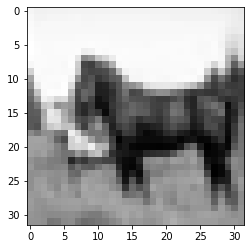

```python
import pandas as pd
import numpy as np
import matplotlib.image as mpimg
import cv2
import matplotlib.pyplot as plt
from sklearn.model_selection import train_test_split
from sklearn import preprocessing
from itertools import chain

def processImg(path, mini, maxi):
    img = np.array(cv2.imread(path))
    return np.dot(img[...,:3], [0.2989, 0.5870, 0.1140])

ds = pd.read_csv('./cifar_dataset/labels.csv')
ds['label'] = ds[['label']].apply(preprocessing.LabelEncoder().fit_transform)
imgs = [processImg('./cifar_dataset/data/'+str(id)+'.png', mini, maxi) for id in ds['id']]

mini, maxi = 256, 0
for img in imgs:
    mini = min(np.min(img), mini)
    maxi = max(np.max(img), maxi)
print('min channel value',mini,' max channel value', maxi)

target = ds['label']
ds = ds.drop(columns = ['label'], axis=1)
X_train, X_test, y_train, y_test = train_test_split(ds, target, test_size = 0.2, random_state=1)
plt.imshow(imgs[3], cmap=plt.get_cmap('gray'))
```

##### با توجه به خروجی نشان داده شده، مقدار هر پیکسل بین صفر تا ۲۵۵ می باشد که یعنی هر یک از رنگ های red و green و blue با ۸ بیت نمایش داده می شوند.

#### نشان دادن یک عکس از هر کلاس

##### با بررسی داده ها می دانیم عکس اول در داده های آموزشی مربوط به کلاس اسب و عکس دوم مربوط به کلاس گربه است.

```
class code: 1
```

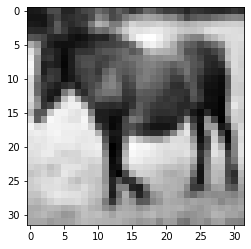

```python
plt.imshow(imgs[0], cmap=plt.get_cmap('gray'))
print('class code:', y_train[0])
```

```
class code: 0
```

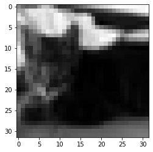

```python
plt.imshow(imgs[1], cmap=plt.get_cmap('gray'))
print('class code:', y_train[1])
```

#### scale کردن داده ها

##### در شبکه های عصبی یادگیری به صورت آپدیت کردن وزن ها انجام می شود. به این صورت که وزن جدید برابر با وزن قدیمی به اضافه ضریب یادگیری در مشتق خطا بر حسب همان وزن است. به این ترتیب در صورتی که عدد مربوط به یک کانال یک پیکسل، عددی بزرگ مانند ۲۵۵ باشد، مقداری که تغییرات آن روی وزن تاثیر می گذارد به نسبت یک کانال پیکسل با عدد کوچکتر بسیار بیشتر می شود در حالیکه تاثیر آن در عکس ممکن است به این اندازه از پیکسل دیگر بزرگتر نباشد. به عبارتی ممکن است میزان تاثیر یک کانال پیکسل را دست بالا و دست کم بگیریم که مطلوب نیست. پس بهتر است بازه ورودی ها را بین صفر و یک بیاوریم که تفاوت در مقدار ناچیز باشد و این اتفاق نیوفتد. از آنجایی که هنگام خواندن ورودی این کار انجام می شود، در اینجا فقط تابعی که اینکار را انجام می دهد نمایش داده شده است.

##### در قطعه کد زیر ابتدا مقادیر پیکسل ها را به ۲۵۵ تقسیم می کنیم تا بین صفر و یک بشود و سپس ماتریس های دوبعدی تصاویر را برای ورود به شبکه عصبی به صورت یک بعدی در می آوریم و ایندکس ها را برای تقسیم داده ها به بچ ریست می کنیم تا به ترتیب درست باشند.

```python
imgs = [list(chain.from_iterable(mat)) for mat in imgs]
imgs_df = pd.DataFrame(imgs)
imgs_df /= 255
X_train, X_test, y_train, y_test = train_test_split(imgs_df, target, test_size = 0.2, random_state=1)
```

```python
X_test
```

|  | 0 | 1 | 2 | 3 | 4 | 5 | 6 | 7 | 8 | 9 | ... | 1014 | 1015 | 1016 | 1017 | 1018 | 1019 | 1020 | 1021 | 1022 | 1023 |
| --- | --- | --- | --- | --- | --- | --- | --- | --- | --- | --- | --- | --- | --- | --- | --- | --- | --- | --- | --- | --- | --- |
| 9953 | 0.999900 | 0.999900 | 0.999900 | 0.999900 | 0.999900 | 0.999900 | 0.999900 | 0.999900 | 0.999900 | 0.999900 | ... | 0.674442 | 0.674442 | 0.674442 | 0.674442 | 0.674442 | 0.674442 | 0.694048 | 0.768551 | 0.843053 | 0.921476 |
| 3850 | 0.280122 | 0.276031 | 0.268062 | 0.236162 | 0.256197 | 0.152036 | 0.052352 | 0.031834 | 0.037948 | 0.064284 | ... | 0.435346 | 0.394279 | 0.337147 | 0.376746 | 0.469447 | 0.380601 | 0.363744 | 0.370414 | 0.409626 | 0.415698 |
| 4962 | 0.136673 | 0.102422 | 0.255625 | 0.228817 | 0.287635 | 0.327445 | 0.342682 | 0.418996 | 0.421153 | 0.430531 | ... | 0.498000 | 0.500109 | 0.513322 | 0.490732 | 0.506350 | 0.515086 | 0.505456 | 0.505456 | 0.495480 | 0.518560 |
| 3886 | 0.285266 | 0.273907 | 0.278638 | 0.278234 | 0.136902 | 0.209507 | 0.289061 | 0.295048 | 0.292021 | 0.299821 | ... | 0.407058 | 0.417160 | 0.402369 | 0.413003 | 0.413003 | 0.415752 | 0.397318 | 0.381229 | 0.349859 | 0.372214 |
| 5437 | 0.315750 | 0.456152 | 0.513224 | 0.481594 | 0.433645 | 0.429277 | 0.433198 | 0.477056 | 0.465015 | 0.367172 | ... | 0.184235 | 0.157487 | 0.171831 | 0.380910 | 0.427510 | 0.285285 | 0.176393 | 0.456965 | 0.381519 | 0.227041 |
| ... | ... | ... | ... | ... | ... | ... | ... | ... | ... | ... | ... | ... | ... | ... | ... | ... | ... | ... | ... | ... | ... |
| 3919 | 0.561647 | 0.544343 | 0.594871 | 0.608937 | 0.421445 | 0.431312 | 0.691855 | 0.825175 | 0.857270 | 0.881075 | ... | 0.664907 | 0.674604 | 0.656853 | 0.648564 | 0.667891 | 0.670405 | 0.663287 | 0.660091 | 0.679697 | 0.688990 |
| 162 | 0.666262 | 0.667272 | 0.657980 | 0.651950 | 0.652059 | 0.586057 | 0.487514 | 0.448471 | 0.439693 | 0.452375 | ... | 0.367958 | 0.379039 | 0.379891 | 0.365783 | 0.364206 | 0.358708 | 0.357300 | 0.369891 | 0.373577 | 0.434214 |
| 7903 | 0.175563 | 0.172367 | 0.172814 | 0.186753 | 0.405173 | 0.582207 | 0.344694 | 0.195278 | 0.203501 | 0.203948 | ... | 0.447986 | 0.210467 | 0.154627 | 0.160361 | 0.164282 | 0.168204 | 0.174874 | 0.181949 | 0.185870 | 0.189791 |
| 2242 | 0.000000 | 0.000000 | 0.000000 | 0.000000 | 0.000000 | 0.000000 | 0.000000 | 0.000000 | 0.000000 | 0.000000 | ... | 0.000000 | 0.000000 | 0.000000 | 0.000000 | 0.000000 | 0.000000 | 0.000000 | 0.000000 | 0.000000 | 0.000000 |
| 2745 | 0.936074 | 0.932153 | 0.938823 | 0.937651 | 0.937651 | 0.937651 | 0.937651 | 0.937651 | 0.937651 | 0.937651 | ... | 0.829487 | 0.477120 | 0.000000 | 0.069536 | 0.616831 | 0.777786 | 0.708462 | 0.712830 | 0.684614 | 0.643058 |

2000 rows × 1024 columns

```python
y_train = y_train.reset_index()
y_test = y_test.reset_index()
X_train = X_train.reset_index()
X_test = X_test.reset_index()
del y_train['index']
del y_test['index']
del X_train['index']
del X_test['index']
```

#### بدست آوردن تعداد داده های هر کلاس در داده های آموزشی و تست

##### با بررسی دیتافریم بعد از label encoding می دانیم لیبل ۱ مربوط به اسب و لیبل ۰ مربوط به گربه است. با استفاده از تابع count مقدار هر کدام را در داده های تست و آموزشی شمرده و نمودار میله ای این مقادیر را رسم می کنیم.

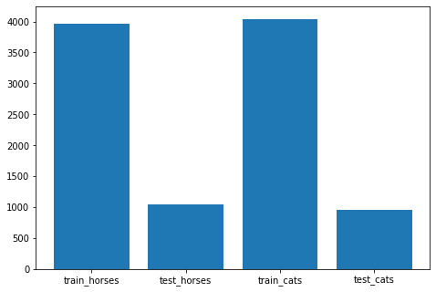

```python
import matplotlib.pyplot as plt

nums = [len(y_train[y_train==1]), len(y_test[y_test==1]), len(y_train[y_train==0]), len(y_test[y_test==0])]
labels = ['train_horses', 'test_horses', 'train_cats', 'test_cats']

ax = plt.figure().add_axes([0,0,1,1])
ax.bar(labels, nums)
plt.show()
```

### بخش دوم: تکمیل بخش های ناقص شبکه عصبی

# Dataloader

```python
from sklearn.utils import shuffle

class Dataloader:
    def __init__(self, data, labels, n_classes, batch_size=None, shuffle=False):
        assert len(data)==len(labels)
        self.__n_classes = n_classes
        self.__batch_size = batch_size
        self.__shuffle = shuffle
        self.__data = data
        self.__onehot_labels = self.__onehot(labels, self.__n_classes)

    def __onehot(self, labels, n_classes):
        labels_list = labels.to_list()
        return [[not label, label] for label in labels_list]

    def __shuffle_dataset(self):
        self.__data, self.__onehot_labels = shuffle(self.__data, self.__onehot_labels)

    def __iter__(self):
        if self.__shuffle:
            self.__shuffle_dataset()

        if self.__batch_size==None:
            yield (np.matrix(self.__data), np.matrix(self.__onehot_labels))
            return

        for idx in range(0, len(self.__data), self.__batch_size):
            yield (np.matrix(self.__data[idx:idx+self.__batch_size]),
                   np.matrix(self.__onehot_labels[idx:idx+self.__batch_size]))
```

# Activation Functions

```python
import matplotlib.pyplot as plt
import copy
from numpy import array, exp

class Identical:
    def __init__(self): pass

    def __val(self, matrix):
        return matrix

    def derivative(self, matrix):
        return matrix*0+1

    def __call__(self, matrix):
        return self.__val(matrix)


class Relu:
    def __init__(self): pass

    def __val(self, matrix):
        return  np.maximum(matrix, 0)

    def derivative(self, matrix):
        Relu_derivative = copy.deepcopy(matrix)
        Relu_derivative[Relu_derivative <= 0], Relu_derivative[Relu_derivative > 0] = 0., 1.
        return Relu_derivative

    def __call__(self, matrix):
        return self.__val(matrix)


class LeakyRelu:
    def __init__(self, negative_slope=0.01):
        self.negative_slope = 0.01

    def __val(self, matrix):
        temp = np.matrix(matrix, dtype=float)
        return np.matrix(np.where(temp > 0, temp, temp * self.negative_slope))

    def derivative(self, matrix):
        temp = np.matrix(matrix, dtype=float)
        return np.matrix(np.where(temp > 0, 1, self.negative_slope))

    def __call__(self, matrix):
        return self.__val(matrix)


class Sigmoid:
    def __init__(self): pass

    def __val(self, matrix):
        return 1 / (1 + exp(-array(matrix)))

    def derivative(self, matrix):
        return self.__val(matrix)*(1. - self.__val(matrix))

    def __call__(self, matrix):
        return self.__val(matrix)


class Softmax:
    def __init__(self): pass

    def __val(self, matrix):
        exps = np.exp(matrix)
        return exps / exps.sum(axis=1)

    def __call__(self, matrix):
        return self.__val(matrix)


class Tanh:
    def __init__(self): pass

    def __val(self, matrix):
        return np.tanh(array(matrix))

    def derivative(self, matrix):
        return 1-self.__val(matrix)**2

    def __call__(self, matrix):
        return self.__val(matrix)
```

# Loss Function

```python
import numpy as np

class CrossEntropy: #(with softmax)
    def __init__(self): pass

    def __val(self, true_val, expected_val):
        assert np.shape(true_val)==np.shape(expected_val)
        sm = Softmax()
        sm_log = np.log(sm(true_val))
        return -np.dot(np.matrix(expected_val, dtype=float), sm_log.T)

    def derivative(self, true_val, expected_val):
        assert np.shape(true_val)==np.shape(expected_val)
        sm = Softmax()
        return sm(true_val) - expected_val

    def __call__(self, true_val, expected_val):
        return self.__val(true_val, expected_val)
```

# Layer

```
forward and back propagation visualization:
```

[figure not shown]

```python
class Layer:
    DEFAULT_LOW, DEFAULT_HIGH, DEFAULT_MEAN, DEFAULT_VAR = 0, 0.05, 0., 1.

    def __init__(self, input_size, output_size, activation=Identical(), initial_weight='uniform',
                 **initializing_parameters):
        assert type(initial_weight)==str, 'Undefined activation function!'

        self.__weight_initializer_dict = {'uniform':self.__uniform_weight, 'normal':self.__normal_weight, 'zero': self.__zeros}

        assert initial_weight in self.__weight_initializer_dict, 'Undefined weight initialization function!'


        self.__n_neurons = output_size
        weight_initializer = self.__weight_initializer_dict[initial_weight]
        self.__weight = weight_initializer(input_size, self.__n_neurons, **initializing_parameters)
        self.__bias = weight_initializer(1, self.__n_neurons, **initializing_parameters)
        self.__activation = activation

        self.__last_input = None
        self.__last_activation_input = None
        self.__last_activation_output = None
        self.__last_activation_derivative = None

    def forward(self, layer_input):
        assert np.ndim(layer_input) == 2
        assert np.size(self.__weight,0) == np.size(layer_input,1)

        self.__last_input = layer_input
        self.__last_activation_input = np.dot(self.__last_input, self.__weight) + self.__bias
        self.__last_activation_output = self.__activation(self.__last_activation_input)
        self.__last_activation_derivative = self.__activation.derivative(self.__last_activation_output)

        return self.__last_activation_output

    def update_weights(self, backprop_tensor, lr):
        assert np.ndim(backprop_tensor) == 2
        assert np.size(backprop_tensor,0) == np.size(self.__last_activation_derivative,0)
        assert np.size(backprop_tensor,1) == self.__n_neurons

        sfd = np.multiply(backprop_tensor,self.__last_activation_derivative)
        backprop_tensor = np.matmul(sfd,self.__weight.T)

        self.__weight -= np.matmul(self.__last_input.T,sfd)*lr
        self.__bias -= np.matmul(np.matrix([[1]*backprop_tensor.shape[0]]),sfd)*lr

        return backprop_tensor


    def __uniform_weight(self, dim1, dim2, **initializing_parameters):
        low, high = self.DEFAULT_LOW, self.DEFAULT_HIGH
        if 'low' in initializing_parameters.keys(): low = initializing_parameters['low']
        if 'high' in initializing_parameters.keys(): high = initializing_parameters['high']
        return np.random.uniform(low=low, high=high, size=(dim1, dim2))

    def __normal_weight(self, dim1, dim2, **initializing_parameters):
        mean, var = self.DEFAULT_MEAN, self.DEFAULT_VAR
        if 'mean' in initializing_parameters.keys(): mean = initializing_parameters['mean']
        if 'var' in initializing_parameters.keys(): var = initializing_parameters['var']
        return np.random.normal(loc=mean, scale=var, size=(dim1, dim2))

    def __zeros(self, dim1, dim2):
        return np.array([[0]*dim1]*dim2)

    @property
    def n_neurons(self): return self.__n_neurons

    @property
    def weight(self): return self.__weight

    @property
    def bias(self): return self.__bias

    @property
    def activation(self): return self.__activation
```

# Feed Forward Neural Network

```python
class FeedForwardNN:
    def __init__(self, input_shape):
        self.__input_shape = input_shape
        self.__output_shape = None

        self.__layers_list = []

        self.__lr = None
        self.__loss = None


    def add_layer(self, n_neurons, activation=Relu(), initial_weight='uniform', **initializing_parameters):
        assert type(n_neurons)==int, "Invalid number of neurons for the layer!"
        assert n_neurons>0, "Invalid number of neurons for the layer!"

        n_prev_neurons = self.__input_shape if len(self.__layers_list)==0 else self.__layers_list[-1].n_neurons
        new_layer = Layer(n_prev_neurons, n_neurons, activation, initial_weight, **initializing_parameters)
        self.__layers_list.append(new_layer)
        self.__output_shape = self.__layers_list[-1].n_neurons


    def set_training_param(self, loss=CrossEntropy(), lr=1e-3):
        assert self.__layers_list, "Uncomplete model!"
        self.__loss = loss
        self.__lr = lr


    def forward(self, network_input):
        assert type(self.__output_shape) != None, "Model is not compiled!"
        network_output = network_input
        for layer in self.__layers_list:
            network_output = layer.forward(network_output)
        return network_output


    def fit(self, epochs, trainloader, testloader=None, print_results=True):
        assert type(self.__output_shape) != None, "Model is not compiled!"
        assert type(self.__lr) != None and type(self.__loss) != None, "Training paramenters are not set!"

        log = {"train_accuracy":[], "train_loss":[], "test_accuracy":[], "test_loss":[]}

        for epoch in range(1, epochs+1):

            if print_results:
                print('Epoch {}:'.format(epoch))

            average_accuracy, average_loss = self.__train(trainloader)
            log['train_accuracy'].append(average_accuracy)
            log['train_loss'].append(average_loss)
            if print_results:
                print('\tTrain: Average Accuracy: {}\tAverage Loss: {}'.format(average_accuracy, average_loss))

            if type(testloader) != type(None):
                average_accuracy, average_loss = self.__test(testloader)
                log['test_accuracy'].append(average_accuracy)
                log['test_loss'].append(average_loss)
                if print_results:
                    print('\tTest: Average Accuracy: {}\tAverage Loss: {}'.format(average_accuracy, average_loss))

        return log


    def __train(self, trainloader):
        bach_accuracies, batch_losses = [], []
        for x_train, y_train in trainloader:
            batch_accuracy, batch_loss = self.__perform_on_batch(x_train, y_train, 1)
            bach_accuracies.append(batch_accuracy)
            batch_losses.append(batch_loss)
        return np.mean(bach_accuracies), np.mean(batch_losses)


    def __test(self, testloader):
        bach_accuracies, batch_losses = [], []
        for x_test, y_test in testloader:
            batch_accuracy, batch_loss = self.__perform_on_batch(x_test, y_test, 0)
            bach_accuracies.append(batch_accuracy)
            batch_losses.append(batch_loss)
        return np.mean(bach_accuracies), np.mean(batch_losses)


    def __perform_on_batch(self, x_batch, y_batch, train):
        results = self.forward(x_batch)
        if train:
            self.__update_weights(results, y_batch)
        return (self.__compute_accuracy(results, y_batch), np.mean(self.__loss(results, y_batch)))


    def __get_labels(self, outputs):
        return np.argmax(outputs, axis = 1)


    def __compute_accuracy(self, output, expected_output):
        # accuracy: number of correct predictions / total number of preditions
        ol = self.__get_labels(output)
        eol = self.__get_labels(expected_output)
        return sum([ol[i] == eol[i] for i in range(len(ol))])/output.shape[0]*100


    def __update_weights(self, output, y_train):
        backprop_tensor = self.__loss.derivative(output, y_train)
        for layer in reversed(self.__layers_list):
            backprop_tensor = layer.update_weights(backprop_tensor, self.__lr)
```

### بخش سوم: طبقه بندی داده ها

#### قسمت اول: آموزش شبکه

# Training Sample Code

## Part 1

```
Activation function: Relu
```

```python
INPUT_SHAPE = 1024
LEARNING_RATE = 0.001
EPOCHS = 25
BATCH_SIZE = 32
TRAINLOADER = Dataloader(X_train, y_train, 2, BATCH_SIZE)
TESTLOADER = Dataloader(X_test, y_test, 2, BATCH_SIZE)

network = FeedForwardNN(INPUT_SHAPE)
network.add_layer(50, input_shape=INPUT_SHAPE, activation=Relu(), weight_initializer='uniform')
network.add_layer(2, activation=Identical(), weight_initializer='uniform')
network.set_training_param(loss=CrossEntropy(), lr=LEARNING_RATE)

log = network.fit(EPOCHS, TRAINLOADER, TESTLOADER)
```

```
Epoch 1:
	Train: Average Accuracy: 54.5	Average Loss: 2.6914357598227503
	Test: Average Accuracy: 57.242063492063494	Average Loss: 0.731211851403328
Epoch 2:
	Train: Average Accuracy: 61.175	Average Loss: 0.7275403922448674
	Test: Average Accuracy: 61.65674603174603	Average Loss: 0.7405944471840211
Epoch 3:
	Train: Average Accuracy: 63.7375	Average Loss: 0.7444187176993298
	Test: Average Accuracy: 62.15277777777778	Average Loss: 0.7577660256867202
Epoch 4:
	Train: Average Accuracy: 66.1875	Average Loss: 0.7660206549802571
	Test: Average Accuracy: 64.28571428571429	Average Loss: 0.7810258422442808
Epoch 5:
	Train: Average Accuracy: 68.4875	Average Loss: 0.7937997712154138
	Test: Average Accuracy: 65.0297619047619	Average Loss: 0.8274556510363039
Epoch 6:
	Train: Average Accuracy: 70.275	Average Loss: 0.8259375847911787
	Test: Average Accuracy: 65.37698412698413	Average Loss: 0.869599491700598
Epoch 7:
	Train: Average Accuracy: 71.3125	Average Loss: 0.8573720131417547
	Test: Average Accuracy: 65.67460317460318	Average Loss: 0.9004914176920317
Epoch 8:
	Train: Average Accuracy: 71.7875	Average Loss: 0.8803308256240747
	Test: Average Accuracy: 66.17063492063492	Average Loss: 0.9246737626142253
Epoch 9:
	Train: Average Accuracy: 72.75	Average Loss: 0.8997998923965346
	Test: Average Accuracy: 67.26190476190476	Average Loss: 0.9286381030921167
Epoch 10:
	Train: Average Accuracy: 73.1125	Average Loss: 0.9180415631097489
	Test: Average Accuracy: 68.70039682539682	Average Loss: 0.9379726639088805
Epoch 11:
	Train: Average Accuracy: 73.4625	Average Loss: 0.9314269711342993
	Test: Average Accuracy: 70.08928571428571	Average Loss: 0.9358192409324565
Epoch 12:
	Train: Average Accuracy: 74.075	Average Loss: 0.9446768633711062
	Test: Average Accuracy: 70.28769841269842	Average Loss: 0.951503204848431
Epoch 13:
	Train: Average Accuracy: 74.4	Average Loss: 0.9562310085008261
	Test: Average Accuracy: 70.13888888888889	Average Loss: 0.9518368730126204
Epoch 14:
```

[output cut: 20 more lines]

```
Epoch 21:
	Train: Average Accuracy: 77.425	Average Loss: 1.0428132634768998
	Test: Average Accuracy: 71.57738095238095	Average Loss: 1.0383289364395147
Epoch 22:
	Train: Average Accuracy: 77.725	Average Loss: 1.0518894724329215
	Test: Average Accuracy: 71.2797619047619	Average Loss: 1.062150252570679
Epoch 23:
	Train: Average Accuracy: 78.075	Average Loss: 1.0633934272283596
	Test: Average Accuracy: 71.2797619047619	Average Loss: 1.0772650054039394
Epoch 24:
	Train: Average Accuracy: 78.3125	Average Loss: 1.0758773802754762
	Test: Average Accuracy: 71.23015873015873	Average Loss: 1.1019268307058263
Epoch 25:
	Train: Average Accuracy: 78.8125	Average Loss: 1.0881393360941716
	Test: Average Accuracy: 71.52777777777777	Average Loss: 1.0966621068938578
```

## Part 2

[output not shown]

```python
INPUT_SHAPE = 1024
LEARNING_RATE = 0.001
EPOCHS = 25
BATCH_SIZE = 32
TRAINLOADER = Dataloader(X_train, y_train, 2, BATCH_SIZE)
TESTLOADER = Dataloader(X_test, y_test, 2, BATCH_SIZE)

network = FeedForwardNN(INPUT_SHAPE)
network.add_layer(50, input_shape=INPUT_SHAPE, activation=Relu(), weight_initializer='zero')
network.add_layer(2, activation=Identical(), weight_initializer='zero')
network.set_training_param(loss=CrossEntropy(), lr=LEARNING_RATE)

log = network.fit(EPOCHS, TRAINLOADER, TESTLOADER)
```

```
Epoch 1:
	Train: Average Accuracy: 54.225	Average Loss: 2.6856322919395215
	Test: Average Accuracy: 56.69642857142857	Average Loss: 0.7231301476183247
Epoch 2:
	Train: Average Accuracy: 61.0375	Average Loss: 0.7236386686197355
	Test: Average Accuracy: 61.111111111111114	Average Loss: 0.7324327137626626
Epoch 3:
	Train: Average Accuracy: 63.6	Average Loss: 0.7420419488376059
	Test: Average Accuracy: 62.8968253968254	Average Loss: 0.7473340171998452
Epoch 4:
	Train: Average Accuracy: 65.8375	Average Loss: 0.7648029830666461
	Test: Average Accuracy: 64.53373015873017	Average Loss: 0.7732292130277932
Epoch 5:
	Train: Average Accuracy: 67.7875	Average Loss: 0.7936439494220088
	Test: Average Accuracy: 65.07936507936508	Average Loss: 0.8412614204221935
Epoch 6:
	Train: Average Accuracy: 69.5125	Average Loss: 0.8251331695524848
	Test: Average Accuracy: 65.625	Average Loss: 0.8712708568597762
Epoch 7:
	Train: Average Accuracy: 70.825	Average Loss: 0.8519263686163882
	Test: Average Accuracy: 67.90674603174604	Average Loss: 0.8685508059201619
Epoch 8:
	Train: Average Accuracy: 71.5375	Average Loss: 0.8724929317905439
	Test: Average Accuracy: 67.55952380952381	Average Loss: 0.8808326287976703
Epoch 9:
	Train: Average Accuracy: 72.0125	Average Loss: 0.889253872195074
	Test: Average Accuracy: 69.19642857142857	Average Loss: 0.8959434651279453
Epoch 10:
	Train: Average Accuracy: 72.4125	Average Loss: 0.9044420826517878
	Test: Average Accuracy: 69.44444444444444	Average Loss: 0.9164310694175174
Epoch 11:
	Train: Average Accuracy: 73.0625	Average Loss: 0.9213062699492018
	Test: Average Accuracy: 69.04761904761905	Average Loss: 0.9367450964103716
Epoch 12:
	Train: Average Accuracy: 73.4875	Average Loss: 0.9351893894200448
	Test: Average Accuracy: 69.24603174603175	Average Loss: 0.9450783786168738
Epoch 13:
	Train: Average Accuracy: 74.3875	Average Loss: 0.9472959268262048
	Test: Average Accuracy: 68.40277777777777	Average Loss: 0.958784346606998
Epoch 14:
```

[output cut: 20 more lines]

```
Epoch 21:
	Train: Average Accuracy: 77.525	Average Loss: 1.0335208878706166
	Test: Average Accuracy: 70.38690476190476	Average Loss: 1.0216461211224546
Epoch 22:
	Train: Average Accuracy: 77.775	Average Loss: 1.0462457654849922
	Test: Average Accuracy: 70.38690476190476	Average Loss: 1.0320354936445324
Epoch 23:
	Train: Average Accuracy: 77.825	Average Loss: 1.0606485956002576
	Test: Average Accuracy: 70.08928571428571	Average Loss: 1.046598401913184
Epoch 24:
	Train: Average Accuracy: 78.3875	Average Loss: 1.0749703674717608
	Test: Average Accuracy: 70.68452380952381	Average Loss: 1.0558071168565195
Epoch 25:
	Train: Average Accuracy: 78.7625	Average Loss: 1.0873072934574666
	Test: Average Accuracy: 70.83333333333333	Average Loss: 1.0637770674828178
```

## Part 3

### part 3-1

```
Finding the best learning rate
```

```python
INPUT_SHAPE = 1024
LEARNING_RATE = 0.002
EPOCHS = 25
BATCH_SIZE = 32
TRAINLOADER = Dataloader(X_train, y_train, 2, BATCH_SIZE)
TESTLOADER = Dataloader(X_test, y_test, 2, BATCH_SIZE)

network = FeedForwardNN(INPUT_SHAPE)
network.add_layer(50, input_shape=INPUT_SHAPE, activation=Relu(), weight_initializer='uniform')
network.add_layer(2, activation=Identical(), weight_initializer='uniform')
network.set_training_param(loss=CrossEntropy(), lr=LEARNING_RATE)

log = network.fit(EPOCHS, TRAINLOADER, TESTLOADER)
```

```
Epoch 1:
```

```
	Train: Average Accuracy: 56.4125	Average Loss: inf
	Test: Average Accuracy: 59.523809523809526	Average Loss: 0.6772819934039663
Epoch 2:
	Train: Average Accuracy: 63.3875	Average Loss: 0.6358976522481435
	Test: Average Accuracy: 61.904761904761905	Average Loss: 0.6489133896779884
Epoch 3:
	Train: Average Accuracy: 66.6625	Average Loss: 0.602177451408211
	Test: Average Accuracy: 62.301587301587304	Average Loss: 0.6582370198360132
Epoch 4:
	Train: Average Accuracy: 69.025	Average Loss: 0.5804613525958298
	Test: Average Accuracy: 63.64087301587302	Average Loss: 0.6444702819351322
Epoch 5:
	Train: Average Accuracy: 70.3875	Average Loss: 0.5638210865965657
	Test: Average Accuracy: 64.68253968253968	Average Loss: 0.6159384428117157
Epoch 6:
	Train: Average Accuracy: 71.275	Average Loss: 0.5529072142349084
	Test: Average Accuracy: 66.96428571428571	Average Loss: 0.5871233157153265
Epoch 7:
	Train: Average Accuracy: 71.95	Average Loss: 0.5421980336194959
	Test: Average Accuracy: 66.26984126984127	Average Loss: 0.6034881157644303
Epoch 8:
	Train: Average Accuracy: 72.575	Average Loss: 0.5336259889894677
	Test: Average Accuracy: 67.46031746031746	Average Loss: 0.5874292773239974
Epoch 9:
	Train: Average Accuracy: 73.2125	Average Loss: 0.5268080858886609
	Test: Average Accuracy: 67.90674603174604	Average Loss: 0.5852300076258964
Epoch 10:
	Train: Average Accuracy: 73.45	Average Loss: 0.519718028131561
	Test: Average Accuracy: 68.70039682539682	Average Loss: 0.5808180940945403
Epoch 11:
	Train: Average Accuracy: 74.175	Average Loss: 0.5132436215496243
	Test: Average Accuracy: 69.5436507936508	Average Loss: 0.5689266135792339
Epoch 12:
	Train: Average Accuracy: 74.425	Average Loss: 0.5062998737013135
	Test: Average Accuracy: 69.59325396825396	Average Loss: 0.5674608759023609
Epoch 13:
	Train: Average Accuracy: 75.1375	Average Loss: 0.5005213016895955
	Test: Average Accuracy: 69.14682539682539	Average Loss: 0.577343713484787
Epoch 14:
	Train: Average Accuracy: 75.9875	Average Loss: 0.491957167183096
```

[output cut: 19 more lines]

```
Epoch 21:
	Train: Average Accuracy: 78.875	Average Loss: 0.4481977828734663
	Test: Average Accuracy: 70.53571428571429	Average Loss: 0.5586685614725826
Epoch 22:
	Train: Average Accuracy: 79.3375	Average Loss: 0.44437368856536447
	Test: Average Accuracy: 69.89087301587301	Average Loss: 0.5813836673534012
Epoch 23:
	Train: Average Accuracy: 79.45	Average Loss: 0.43782694064845523
	Test: Average Accuracy: 70.08928571428571	Average Loss: 0.5714387064627267
Epoch 24:
	Train: Average Accuracy: 80.0	Average Loss: 0.4329218425333164
	Test: Average Accuracy: 69.99007936507937	Average Loss: 0.5754098457463241
Epoch 25:
	Train: Average Accuracy: 80.1375	Average Loss: 0.4253448162570113
	Test: Average Accuracy: 70.28769841269842	Average Loss: 0.5705353851973488
```

### part 3-2

```
Learning rate = 0.002 * 0.1
```

```python
INPUT_SHAPE = 1024
LEARNING_RATE = 0.0002
EPOCHS = 25
BATCH_SIZE = 32
TRAINLOADER = Dataloader(X_train, y_train, 2, BATCH_SIZE)
TESTLOADER = Dataloader(X_test, y_test, 2, BATCH_SIZE)

network = FeedForwardNN(INPUT_SHAPE)
network.add_layer(50, input_shape=INPUT_SHAPE, activation=Relu(), weight_initializer='uniform')
network.add_layer(2, activation=Identical(), weight_initializer='uniform')
network.set_training_param(loss=CrossEntropy(), lr=LEARNING_RATE)

log = network.fit(EPOCHS, TRAINLOADER, TESTLOADER)
```

```
Epoch 1:
	Train: Average Accuracy: 50.0625	Average Loss: 6.840659486075944
	Test: Average Accuracy: 52.33134920634921	Average Loss: 7.558581186085134
Epoch 2:
	Train: Average Accuracy: 50.4875	Average Loss: 2.158010104146375
	Test: Average Accuracy: 52.33134920634921	Average Loss: 2.3986169669609123
Epoch 3:
	Train: Average Accuracy: 51.475	Average Loss: 0.9201323026063176
	Test: Average Accuracy: 52.33134920634921	Average Loss: 1.3504040017131451
Epoch 4:
	Train: Average Accuracy: 54.8625	Average Loss: 0.7414242747681506
	Test: Average Accuracy: 52.33134920634921	Average Loss: 1.0050509659282416
Epoch 5:
	Train: Average Accuracy: 56.6125	Average Loss: 0.7069959664300511
	Test: Average Accuracy: 52.529761904761905	Average Loss: 0.8567016609051847
Epoch 6:
	Train: Average Accuracy: 58.275	Average Loss: 0.6898101854362235
	Test: Average Accuracy: 53.86904761904762	Average Loss: 0.7861748831102066
Epoch 7:
	Train: Average Accuracy: 59.65	Average Loss: 0.6779941870990693
	Test: Average Accuracy: 55.208333333333336	Average Loss: 0.7469245301150701
Epoch 8:
	Train: Average Accuracy: 61.225	Average Loss: 0.6688133887731773
	Test: Average Accuracy: 56.99404761904762	Average Loss: 0.7221435403203357
Epoch 9:
	Train: Average Accuracy: 61.95	Average Loss: 0.6615626247556304
	Test: Average Accuracy: 58.18452380952381	Average Loss: 0.7052002484030956
Epoch 10:
	Train: Average Accuracy: 62.1125	Average Loss: 0.6559532356820127
	Test: Average Accuracy: 58.87896825396825	Average Loss: 0.6930684562852656
Epoch 11:
	Train: Average Accuracy: 62.875	Average Loss: 0.6516724871492983
	Test: Average Accuracy: 59.82142857142857	Average Loss: 0.6840981583689861
Epoch 12:
	Train: Average Accuracy: 63.1	Average Loss: 0.648370262391619
	Test: Average Accuracy: 60.267857142857146	Average Loss: 0.6772687833191369
Epoch 13:
	Train: Average Accuracy: 63.4625	Average Loss: 0.6457467807149916
	Test: Average Accuracy: 60.763888888888886	Average Loss: 0.6719232797983781
Epoch 14:
```

[output cut: 20 more lines]

```
Epoch 21:
	Train: Average Accuracy: 65.25	Average Loss: 0.634446147075941
	Test: Average Accuracy: 62.74801587301587	Average Loss: 0.651924295283766
Epoch 22:
	Train: Average Accuracy: 65.5	Average Loss: 0.6335816681916993
	Test: Average Accuracy: 63.04563492063492	Average Loss: 0.6507210138416096
Epoch 23:
	Train: Average Accuracy: 65.525	Average Loss: 0.6327774382909803
	Test: Average Accuracy: 62.99603174603175	Average Loss: 0.6496565041857209
Epoch 24:
	Train: Average Accuracy: 65.575	Average Loss: 0.6320239498944393
	Test: Average Accuracy: 63.04563492063492	Average Loss: 0.6487047517600864
Epoch 25:
	Train: Average Accuracy: 65.5875	Average Loss: 0.6313067336844577
	Test: Average Accuracy: 62.94642857142857	Average Loss: 0.647851473645389
```

### part 3-3

```
Learning rate = 0.002 * 10
```

```python
INPUT_SHAPE = 1024
LEARNING_RATE = 0.02
EPOCHS = 25
BATCH_SIZE = 32
TRAINLOADER = Dataloader(X_train, y_train, 2, BATCH_SIZE)
TESTLOADER = Dataloader(X_test, y_test, 2, BATCH_SIZE)

network = FeedForwardNN(INPUT_SHAPE)
network.add_layer(50, input_shape=INPUT_SHAPE, activation=Relu(), weight_initializer='uniform')
network.add_layer(2, activation=Identical(), weight_initializer='uniform')
network.set_training_param(loss=CrossEntropy(), lr=LEARNING_RATE)

log = network.fit(EPOCHS, TRAINLOADER, TESTLOADER)
```

```
Epoch 1:
```

```
	Train: Average Accuracy: 49.5125	Average Loss: nan
	Test: Average Accuracy: 52.33134920634921	Average Loss: 0.6959424532922537
Epoch 2:
	Train: Average Accuracy: 49.8125	Average Loss: 0.6965325150176184
	Test: Average Accuracy: 52.33134920634921	Average Loss: 0.6959424532922537
Epoch 3:
	Train: Average Accuracy: 49.8125	Average Loss: 0.6965325150176184
	Test: Average Accuracy: 52.33134920634921	Average Loss: 0.6959424532922537
Epoch 4:
	Train: Average Accuracy: 49.8125	Average Loss: 0.6965325150176184
	Test: Average Accuracy: 52.33134920634921	Average Loss: 0.6959424532922537
Epoch 5:
	Train: Average Accuracy: 49.8125	Average Loss: 0.6965325150176184
	Test: Average Accuracy: 52.33134920634921	Average Loss: 0.6959424532922537
Epoch 6:
	Train: Average Accuracy: 49.8125	Average Loss: 0.6965325150176184
	Test: Average Accuracy: 52.33134920634921	Average Loss: 0.6959424532922537
Epoch 7:
	Train: Average Accuracy: 49.8125	Average Loss: 0.6965325150176184
	Test: Average Accuracy: 52.33134920634921	Average Loss: 0.6959424532922537
Epoch 8:
	Train: Average Accuracy: 49.8125	Average Loss: 0.6965325150176184
	Test: Average Accuracy: 52.33134920634921	Average Loss: 0.6959424532922537
Epoch 9:
	Train: Average Accuracy: 49.8125	Average Loss: 0.6965325150176184
	Test: Average Accuracy: 52.33134920634921	Average Loss: 0.6959424532922537
Epoch 10:
	Train: Average Accuracy: 49.8125	Average Loss: 0.6965325150176184
	Test: Average Accuracy: 52.33134920634921	Average Loss: 0.6959424532922537
Epoch 11:
	Train: Average Accuracy: 49.8125	Average Loss: 0.6965325150176184
	Test: Average Accuracy: 52.33134920634921	Average Loss: 0.6959424532922537
Epoch 12:
	Train: Average Accuracy: 49.8125	Average Loss: 0.6965325150176184
	Test: Average Accuracy: 52.33134920634921	Average Loss: 0.6959424532922537
Epoch 13:
	Train: Average Accuracy: 49.8125	Average Loss: 0.6965325150176184
	Test: Average Accuracy: 52.33134920634921	Average Loss: 0.6959424532922537
Epoch 14:
	Train: Average Accuracy: 49.8125	Average Loss: 0.6965325150176184
```

[output cut: 19 more lines]

```
Epoch 21:
	Train: Average Accuracy: 49.8125	Average Loss: 0.6965325150176184
	Test: Average Accuracy: 52.33134920634921	Average Loss: 0.6959424532922537
Epoch 22:
	Train: Average Accuracy: 49.8125	Average Loss: 0.6965325150176184
	Test: Average Accuracy: 52.33134920634921	Average Loss: 0.6959424532922537
Epoch 23:
	Train: Average Accuracy: 49.8125	Average Loss: 0.6965325150176184
	Test: Average Accuracy: 52.33134920634921	Average Loss: 0.6959424532922537
Epoch 24:
	Train: Average Accuracy: 49.8125	Average Loss: 0.6965325150176184
	Test: Average Accuracy: 52.33134920634921	Average Loss: 0.6959424532922537
Epoch 25:
	Train: Average Accuracy: 49.8125	Average Loss: 0.6965325150176184
	Test: Average Accuracy: 52.33134920634921	Average Loss: 0.6959424532922537
```

### Results Review

##### پس از بررسی دقت مدل برای learning rate که ۰.۱ learning rate بهینه است، مشاهده می کنیم که سرعت یادگیری کاهش یافته است. این کاهش به این علت است که کمتر شدن learning rate باعث می شود در فرآیند backpropagation، خطای بدست آمده، تاثیر کمتری روی وزن ها بگذارد و در نتیجه با سرعت کمتری به سمت حالت ایده آل پیش می رویم.

##### پس از بررسی دقت مدل با learning rate برابر با 10 برابر learning rate بهینه، مشاهده می کنیم که پس از یک تغییر جزئی در ایپاک اول، accuracy تغییری نداشته. این عدم تغییر به این علت است که با لرنینگ ریت بسیار بزرگ، تغییرات وزن ها بیش از اندازه به خطا حساس می شوند و این باعث می شود هر خطای جزئی تاثیر زیاد روی وزن هایمان داشته باشد و به این صورت ممکن است تغییرات به حدی بزرگ باشند که وزن های بهینه را هر دفعه رد کنند. در نتیجه اکیورسی زیاد نمی شود.

## Part 4

### part 4-1

```
Activation fuction: Sigmoid
```

```python
INPUT_SHAPE = 1024
LEARNING_RATE = 0.002
EPOCHS = 25
BATCH_SIZE = 32
TRAINLOADER = Dataloader(X_train, y_train, 2, BATCH_SIZE)
TESTLOADER = Dataloader(X_test, y_test, 2, BATCH_SIZE)

network = FeedForwardNN(INPUT_SHAPE)
network.add_layer(50, input_shape=INPUT_SHAPE, activation=Sigmoid(), weight_initializer='uniform')
network.add_layer(2, activation=Identical(), weight_initializer='uniform')
network.set_training_param(loss=CrossEntropy(), lr=LEARNING_RATE)

log = network.fit(EPOCHS, TRAINLOADER, TESTLOADER)
```

```
Epoch 1:
	Train: Average Accuracy: 51.4375	Average Loss: 0.7346770551460896
	Test: Average Accuracy: 52.33134920634921	Average Loss: 0.9612847369524247
Epoch 2:
	Train: Average Accuracy: 51.4125	Average Loss: 0.7356740904302941
	Test: Average Accuracy: 52.33134920634921	Average Loss: 0.960532884817751
Epoch 3:
	Train: Average Accuracy: 51.4125	Average Loss: 0.7355359106721224
	Test: Average Accuracy: 52.33134920634921	Average Loss: 0.9589605817927981
Epoch 4:
	Train: Average Accuracy: 51.3375	Average Loss: 0.7352549257382769
	Test: Average Accuracy: 52.33134920634921	Average Loss: 0.9554489607403124
Epoch 5:
	Train: Average Accuracy: 51.325	Average Loss: 0.734602249558751
	Test: Average Accuracy: 52.33134920634921	Average Loss: 0.9471199767679389
Epoch 6:
	Train: Average Accuracy: 51.225	Average Loss: 0.732950443079397
	Test: Average Accuracy: 52.33134920634921	Average Loss: 0.9267060469073042
Epoch 7:
	Train: Average Accuracy: 51.45	Average Loss: 0.7277600380283107
	Test: Average Accuracy: 52.33134920634921	Average Loss: 0.8724728077629269
Epoch 8:
	Train: Average Accuracy: 54.5	Average Loss: 0.7067538150690966
	Test: Average Accuracy: 52.232142857142854	Average Loss: 0.7834700913486905
Epoch 9:
	Train: Average Accuracy: 58.175	Average Loss: 0.6844194530860255
	Test: Average Accuracy: 55.208333333333336	Average Loss: 0.7260883691075057
Epoch 10:
	Train: Average Accuracy: 60.4375	Average Loss: 0.6675042166286923
	Test: Average Accuracy: 58.28373015873016	Average Loss: 0.6902482554569271
Epoch 11:
	Train: Average Accuracy: 62.2125	Average Loss: 0.6543485837643759
	Test: Average Accuracy: 60.51587301587302	Average Loss: 0.6700442525753624
Epoch 12:
	Train: Average Accuracy: 63.4375	Average Loss: 0.6455725810615977
	Test: Average Accuracy: 61.80555555555556	Average Loss: 0.6609288730654648
Epoch 13:
	Train: Average Accuracy: 64.2	Average Loss: 0.6408405174215765
	Test: Average Accuracy: 61.904761904761905	Average Loss: 0.6562535897165855
Epoch 14:
```

[output cut: 20 more lines]

```
Epoch 21:
	Train: Average Accuracy: 65.4375	Average Loss: 0.6345011465637718
	Test: Average Accuracy: 62.15277777777778	Average Loss: 0.6472229020888216
Epoch 22:
	Train: Average Accuracy: 65.475	Average Loss: 0.6343972592807476
	Test: Average Accuracy: 62.20238095238095	Average Loss: 0.6471669294718543
Epoch 23:
	Train: Average Accuracy: 65.5625	Average Loss: 0.6342859719107182
	Test: Average Accuracy: 62.1031746031746	Average Loss: 0.6471537052690828
Epoch 24:
	Train: Average Accuracy: 65.575	Average Loss: 0.6341564081602881
	Test: Average Accuracy: 62.00396825396825	Average Loss: 0.6471582297334447
Epoch 25:
	Train: Average Accuracy: 65.675	Average Loss: 0.6340013740805129
	Test: Average Accuracy: 62.00396825396825	Average Loss: 0.6471609070331702
```

### part 4-2

```
Activation Function: Tanh
```

```python
INPUT_SHAPE = 1024
LEARNING_RATE = 0.002
EPOCHS = 25
BATCH_SIZE = 32
TRAINLOADER = Dataloader(X_train, y_train, 2, BATCH_SIZE)
TESTLOADER = Dataloader(X_test, y_test, 2, BATCH_SIZE)

network = FeedForwardNN(INPUT_SHAPE)
network.add_layer(50, input_shape=INPUT_SHAPE, activation=Tanh(), weight_initializer='uniform')
network.add_layer(2, activation=Identical(), weight_initializer='uniform')
network.set_training_param(loss=CrossEntropy(), lr=LEARNING_RATE)

log = network.fit(EPOCHS, TRAINLOADER, TESTLOADER)
```

```
Epoch 1:
	Train: Average Accuracy: 51.4375	Average Loss: 0.7348050798292153
	Test: Average Accuracy: 52.33134920634921	Average Loss: 0.962092995998857
Epoch 2:
	Train: Average Accuracy: 51.325	Average Loss: 0.7358325850760833
	Test: Average Accuracy: 52.33134920634921	Average Loss: 0.9615581599560794
Epoch 3:
	Train: Average Accuracy: 51.3625	Average Loss: 0.7354059343708508
	Test: Average Accuracy: 52.33134920634921	Average Loss: 0.9480621000915223
Epoch 4:
	Train: Average Accuracy: 55.3625	Average Loss: 0.709188900137164
	Test: Average Accuracy: 52.976190476190474	Average Loss: 0.7534900661991456
Epoch 5:
	Train: Average Accuracy: 60.65	Average Loss: 0.6636427931941628
	Test: Average Accuracy: 60.11904761904762	Average Loss: 0.6654345837742411
Epoch 6:
	Train: Average Accuracy: 63.25	Average Loss: 0.6394852715389473
	Test: Average Accuracy: 60.714285714285715	Average Loss: 0.6453163425095406
Epoch 7:
	Train: Average Accuracy: 64.1375	Average Loss: 0.6269978344194356
	Test: Average Accuracy: 61.35912698412698	Average Loss: 0.6395687732138138
Epoch 8:
	Train: Average Accuracy: 65.15	Average Loss: 0.6186626737126125
	Test: Average Accuracy: 61.75595238095238	Average Loss: 0.6351939155709583
Epoch 9:
	Train: Average Accuracy: 65.9375	Average Loss: 0.6114660630168995
	Test: Average Accuracy: 62.79761904761905	Average Loss: 0.6304582615745169
Epoch 10:
	Train: Average Accuracy: 66.775	Average Loss: 0.6043299801705279
	Test: Average Accuracy: 63.492063492063494	Average Loss: 0.6256363807705148
Epoch 11:
	Train: Average Accuracy: 67.2	Average Loss: 0.5969610521063652
	Test: Average Accuracy: 64.23611111111111	Average Loss: 0.6196421854511796
Epoch 12:
	Train: Average Accuracy: 68.2125	Average Loss: 0.5896403667293427
	Test: Average Accuracy: 64.68253968253968	Average Loss: 0.6125396624064154
Epoch 13:
	Train: Average Accuracy: 68.9375	Average Loss: 0.5829645696215026
	Test: Average Accuracy: 65.27777777777777	Average Loss: 0.6060877949894932
Epoch 14:
```

[output cut: 20 more lines]

```
Epoch 21:
	Train: Average Accuracy: 71.6625	Average Loss: 0.5481392350261141
	Test: Average Accuracy: 67.31150793650794	Average Loss: 0.582391264371149
Epoch 22:
	Train: Average Accuracy: 71.8875	Average Loss: 0.5451834922191754
	Test: Average Accuracy: 67.50992063492063	Average Loss: 0.5804233122283756
Epoch 23:
	Train: Average Accuracy: 72.025	Average Loss: 0.5424181882388682
	Test: Average Accuracy: 67.60912698412699	Average Loss: 0.5784844178109861
Epoch 24:
	Train: Average Accuracy: 72.1375	Average Loss: 0.5398576794300735
	Test: Average Accuracy: 67.70833333333333	Average Loss: 0.5765963247784635
Epoch 25:
	Train: Average Accuracy: 72.2	Average Loss: 0.5374886525385852
	Test: Average Accuracy: 67.80753968253968	Average Loss: 0.5748008907332345
```

### part 4-3

```
Activation Function: Leaky Relu
```

```python
INPUT_SHAPE = 1024
LEARNING_RATE = 0.002
EPOCHS = 25
BATCH_SIZE = 32
TRAINLOADER = Dataloader(X_train, y_train, 2, BATCH_SIZE)
TESTLOADER = Dataloader(X_test, y_test, 2, BATCH_SIZE)

network = FeedForwardNN(INPUT_SHAPE)
network.add_layer(50, input_shape=INPUT_SHAPE, activation=LeakyRelu(), weight_initializer='uniform')
network.add_layer(2, activation=Identical(), weight_initializer='uniform')
network.set_training_param(loss=CrossEntropy(), lr=LEARNING_RATE)

log = network.fit(EPOCHS, TRAINLOADER, TESTLOADER)
```

```
Epoch 1:
```

```
	Train: Average Accuracy: 56.7	Average Loss: inf
	Test: Average Accuracy: 59.42460317460318	Average Loss: 0.6753226109384902
Epoch 2:
	Train: Average Accuracy: 63.225	Average Loss: 0.6334351750843573
	Test: Average Accuracy: 59.970238095238095	Average Loss: 0.6863321065175405
Epoch 3:
	Train: Average Accuracy: 67.1125	Average Loss: 0.6007199177571995
	Test: Average Accuracy: 62.99603174603175	Average Loss: 0.6484487882068163
Epoch 4:
	Train: Average Accuracy: 69.3625	Average Loss: 0.5786255603895472
	Test: Average Accuracy: 64.6329365079365	Average Loss: 0.62656567191337
Epoch 5:
	Train: Average Accuracy: 70.5125	Average Loss: 0.5642539095924267
	Test: Average Accuracy: 65.52579365079364	Average Loss: 0.6071744802744186
Epoch 6:
	Train: Average Accuracy: 71.6375	Average Loss: 0.5499301780203085
	Test: Average Accuracy: 67.41071428571429	Average Loss: 0.5909141157039202
Epoch 7:
	Train: Average Accuracy: 72.2375	Average Loss: 0.5393568353138555
	Test: Average Accuracy: 67.7579365079365	Average Loss: 0.5817265205514481
Epoch 8:
	Train: Average Accuracy: 73.25	Average Loss: 0.5294271571790625
	Test: Average Accuracy: 68.84920634920636	Average Loss: 0.572880357889732
Epoch 9:
	Train: Average Accuracy: 73.85	Average Loss: 0.5204539959753514
	Test: Average Accuracy: 67.21230158730158	Average Loss: 0.5967411626858248
Epoch 10:
	Train: Average Accuracy: 74.5375	Average Loss: 0.5130535344452422
	Test: Average Accuracy: 68.84920634920636	Average Loss: 0.5741226250570152
Epoch 11:
	Train: Average Accuracy: 74.95	Average Loss: 0.505263030366646
	Test: Average Accuracy: 68.89880952380952	Average Loss: 0.5698443765379162
Epoch 12:
	Train: Average Accuracy: 75.5125	Average Loss: 0.4965856651049261
	Test: Average Accuracy: 68.30357142857143	Average Loss: 0.5871081213271523
Epoch 13:
	Train: Average Accuracy: 75.7	Average Loss: 0.4898905550056254
	Test: Average Accuracy: 70.03968253968254	Average Loss: 0.5529410751366061
Epoch 14:
	Train: Average Accuracy: 76.425	Average Loss: 0.484138910903932
```

[output cut: 19 more lines]

```
Epoch 21:
	Train: Average Accuracy: 79.0125	Average Loss: 0.444157901253206
	Test: Average Accuracy: 69.94047619047619	Average Loss: 0.5781903838543507
Epoch 22:
	Train: Average Accuracy: 79.775	Average Loss: 0.43670811357799344
	Test: Average Accuracy: 69.14682539682539	Average Loss: 0.6047587216852427
Epoch 23:
	Train: Average Accuracy: 79.6375	Average Loss: 0.4340535386114989
	Test: Average Accuracy: 72.02380952380952	Average Loss: 0.5353068235522644
Epoch 24:
	Train: Average Accuracy: 80.4125	Average Loss: 0.42655129594922514
	Test: Average Accuracy: 69.3452380952381	Average Loss: 0.6131483001112881
Epoch 25:
	Train: Average Accuracy: 80.3625	Average Loss: 0.42415293857638653
	Test: Average Accuracy: 72.27182539682539	Average Loss: 0.5339377212989959
```

### Results Review

##### مشاهده می شود که LeakyRelu بهتر از Relu و Tanh و Sigmoid هر دو بدتر از Relu عمل کردند.

##### علت عملکرد نامناسب Sigmoid و Tanh

##### تابع sigmoid و tanh برای مقادیر مثبت بزرگ یا مقادیر منفی کوچک، بی تغییر باقی می مانند که باعث می شود هنگام عملیات back propagation، با مشکل vanishing gradient مواجه بشویم. بعنی مقدار gradient محلی به قدری کوچک است که عملا حساسیت خروجی به آن بسیار کم شده و یادگیری اتفاق نمی افتد. درواقع مقدار مشتق به صفر بسیار نزدیک است و وزن ها تغییر بسیار کمی پیدا می کنند. این مشکل با Relu حل می شود.

##### برتری Leaky Relu نسبت به Relu

##### تابع فعالسازی Relu و مشتق آن برای مقادیر کمتر از صفر مقدار صفر را در نظر می گیرند. پس در صورتیکه مقدار ورودی مشتق آن هنگام back propagation کوچکتر از صفر باشد، لرنینگ ریت در صفر ضرب می شود و عملا وزن تغییری نمی کند و در نتیجه یادگیری انجام نمی شود. به این اتفاق، Dead Relu problem می گویند که باعث کند شدن فرآیند یادگیری می شود. Leaky Relu با گذاشتن یک شیب کم برای مقادیر منفی به جای کاملا صفر، این مشکل را برطرف میکند و باعث تسریع فرآیند یادگیری می شود.

## Part 5

### part 5-1

```
Batch size = 16
```

```python
INPUT_SHAPE = 1024
LEARNING_RATE = 0.002
EPOCHS = 25
BATCH_SIZE = 16
TRAINLOADER = Dataloader(X_train, y_train, 2, BATCH_SIZE)
TESTLOADER = Dataloader(X_test, y_test, 2, BATCH_SIZE)

network = FeedForwardNN(INPUT_SHAPE)
network.add_layer(50, input_shape=INPUT_SHAPE, activation=LeakyRelu(), weight_initializer='uniform')
network.add_layer(2, activation=Identical(), weight_initializer='uniform')
network.set_training_param(loss=CrossEntropy(), lr=LEARNING_RATE)

log = network.fit(EPOCHS, TRAINLOADER, TESTLOADER)
```

```
Epoch 1:
	Train: Average Accuracy: 57.1125	Average Loss: 1.6669793965196675
	Test: Average Accuracy: 59.65	Average Loss: 0.6788062704631666
Epoch 2:
	Train: Average Accuracy: 63.9125	Average Loss: 0.6365938837152118
	Test: Average Accuracy: 60.9	Average Loss: 0.6551615605061676
Epoch 3:
	Train: Average Accuracy: 66.7375	Average Loss: 0.6031879645677468
	Test: Average Accuracy: 62.8	Average Loss: 0.6410152236119414
Epoch 4:
	Train: Average Accuracy: 69.65	Average Loss: 0.5756825238040946
	Test: Average Accuracy: 64.0	Average Loss: 0.6331755503594431
Epoch 5:
	Train: Average Accuracy: 70.85	Average Loss: 0.5587453591469337
	Test: Average Accuracy: 64.75	Average Loss: 0.637021562967272
Epoch 6:
	Train: Average Accuracy: 71.95	Average Loss: 0.5450493859615472
	Test: Average Accuracy: 65.9	Average Loss: 0.5969406431630507
Epoch 7:
	Train: Average Accuracy: 72.775	Average Loss: 0.5338933881756954
	Test: Average Accuracy: 66.6	Average Loss: 0.5967887017989137
Epoch 8:
	Train: Average Accuracy: 73.55	Average Loss: 0.5239347304264288
	Test: Average Accuracy: 66.55	Average Loss: 0.5991427728883468
Epoch 9:
	Train: Average Accuracy: 74.325	Average Loss: 0.5148690481721633
	Test: Average Accuracy: 67.55	Average Loss: 0.5950099369852144
Epoch 10:
	Train: Average Accuracy: 75.0125	Average Loss: 0.505645498457214
	Test: Average Accuracy: 66.95	Average Loss: 0.6032389268318507
Epoch 11:
	Train: Average Accuracy: 75.5125	Average Loss: 0.4975242494823292
	Test: Average Accuracy: 67.0	Average Loss: 0.612858903495014
Epoch 12:
	Train: Average Accuracy: 75.975	Average Loss: 0.48932561890655335
	Test: Average Accuracy: 67.4	Average Loss: 0.6016392285851393
Epoch 13:
	Train: Average Accuracy: 76.625	Average Loss: 0.48298649102297403
	Test: Average Accuracy: 67.7	Average Loss: 0.5868868511069921
Epoch 14:
```

[output cut: 20 more lines]

```
Epoch 21:
	Train: Average Accuracy: 79.85	Average Loss: 0.4273655896931573
	Test: Average Accuracy: 68.2	Average Loss: 0.6104908586452723
Epoch 22:
	Train: Average Accuracy: 80.35	Average Loss: 0.421204044719964
	Test: Average Accuracy: 68.05	Average Loss: 0.6216784331393209
Epoch 23:
	Train: Average Accuracy: 80.7625	Average Loss: 0.4161470424213266
	Test: Average Accuracy: 67.6	Average Loss: 0.6517733434027746
Epoch 24:
	Train: Average Accuracy: 81.0125	Average Loss: 0.4080549186748245
	Test: Average Accuracy: 67.7	Average Loss: 0.6587249705616417
Epoch 25:
	Train: Average Accuracy: 81.4375	Average Loss: 0.40096734900017666
	Test: Average Accuracy: 67.85	Average Loss: 0.6566427157373073
```

### part 5-2

```
Batch size = 256
```

```python
INPUT_SHAPE = 1024
LEARNING_RATE = 0.0002
EPOCHS = 25
BATCH_SIZE = 256
TRAINLOADER = Dataloader(X_train, y_train, 2, BATCH_SIZE)
TESTLOADER = Dataloader(X_test, y_test, 2, BATCH_SIZE)

network = FeedForwardNN(INPUT_SHAPE)
network.add_layer(50, input_shape=INPUT_SHAPE, activation=LeakyRelu(), weight_initializer='uniform')
network.add_layer(2, activation=Identical(), weight_initializer='uniform')
network.set_training_param(loss=CrossEntropy(), lr=LEARNING_RATE)

log = network.fit(EPOCHS, TRAINLOADER, TESTLOADER)
```

```
Epoch 1:
	Train: Average Accuracy: 49.20654296875	Average Loss: 11.228168178896311
	Test: Average Accuracy: 52.1484375	Average Loss: 0.6912234440694205
Epoch 2:
	Train: Average Accuracy: 51.94091796875	Average Loss: 0.6929902058270864
	Test: Average Accuracy: 56.80213341346154	Average Loss: 0.6873634905314272
Epoch 3:
	Train: Average Accuracy: 54.94384765625	Average Loss: 0.6853925597314543
	Test: Average Accuracy: 58.42097355769231	Average Loss: 0.6797848010094242
Epoch 4:
	Train: Average Accuracy: 58.056640625	Average Loss: 0.6757477103251386
	Test: Average Accuracy: 58.86042668269231	Average Loss: 0.6731114665600166
Epoch 5:
	Train: Average Accuracy: 59.48486328125	Average Loss: 0.6683693942680147
	Test: Average Accuracy: 60.505558894230774	Average Loss: 0.6682331864408835
Epoch 6:
	Train: Average Accuracy: 60.48583984375	Average Loss: 0.6624136161940999
	Test: Average Accuracy: 61.54221754807692	Average Loss: 0.6633153782775216
Epoch 7:
	Train: Average Accuracy: 61.29150390625	Average Loss: 0.6565238018146635
	Test: Average Accuracy: 61.68494591346154	Average Loss: 0.6579869242521076
Epoch 8:
	Train: Average Accuracy: 61.92626953125	Average Loss: 0.651262360376132
	Test: Average Accuracy: 62.46243990384615	Average Loss: 0.6527341925905138
Epoch 9:
	Train: Average Accuracy: 62.60986328125	Average Loss: 0.6458024163615749
	Test: Average Accuracy: 63.60802283653846	Average Loss: 0.6477945674595571
Epoch 10:
	Train: Average Accuracy: 62.95166015625	Average Loss: 0.6409842868736585
	Test: Average Accuracy: 64.208984375	Average Loss: 0.6432128351684085
Epoch 11:
	Train: Average Accuracy: 63.51318359375	Average Loss: 0.6363719532520532
	Test: Average Accuracy: 64.69350961538461	Average Loss: 0.6387633802767073
Epoch 12:
	Train: Average Accuracy: 63.8916015625	Average Loss: 0.632411119948819
	Test: Average Accuracy: 64.67848557692308	Average Loss: 0.6344661970615593
Epoch 13:
	Train: Average Accuracy: 64.2822265625	Average Loss: 0.6289346559921032
	Test: Average Accuracy: 65.23813100961539	Average Loss: 0.6304315633863008
Epoch 14:
```

[output cut: 20 more lines]

```
Epoch 21:
	Train: Average Accuracy: 67.29736328125	Average Loss: 0.5998006015093982
	Test: Average Accuracy: 67.68704927884616	Average Loss: 0.6008027474455684
Epoch 22:
	Train: Average Accuracy: 67.529296875	Average Loss: 0.5962753666654697
	Test: Average Accuracy: 68.12650240384616	Average Loss: 0.5970929685694311
Epoch 23:
	Train: Average Accuracy: 67.78564453125	Average Loss: 0.5927469088775588
	Test: Average Accuracy: 68.69741586538461	Average Loss: 0.5933562091099784
Epoch 24:
	Train: Average Accuracy: 68.2861328125	Average Loss: 0.588694300227097
	Test: Average Accuracy: 69.34344951923077	Average Loss: 0.5897437586205386
Epoch 25:
	Train: Average Accuracy: 68.73779296875	Average Loss: 0.5857362583495251
	Test: Average Accuracy: 69.55003004807692	Average Loss: 0.5862290460425645
```

### Results Review

##### علت استفاده از batch

##### در شبکه های عصبی به دو علت از batch استفاده می شود:

##### ۱. کاهش حافظه استفاده شده برای نگهداری داده ها و اجرای عملیت های مرتبط با neural network. چراکه در صورتی که دیتا ها به صورت batch نباشند باید خطای همه آنها را ذخیره کرد تا در انتها وزن ها را بر اساس آنها آپدیت کنیم.

##### ۲. افزایش سرعت با استفاده از خواص vectoriztion و آپدیت کردن وزنها پس از forward propagation هر batch

##### معایب batch های بسیار کوچک

##### استفاده از batch های بسیار کوچک ممکن است باعث ایجاد نویز بسیار زیاد در gradient estimation بشود که ممکن است در پایان ما را به جای مینیمم جهانی به مینیم های محلی هدایت کند و یا اصلا در به یک اکیورسی همگرا نشود. همچنین استفاده از بچ های کوچک باعث ایجاد sample bias می شود. به این معنی که هنگامی که وزن ها را با استفاده از یک بچ خیلی کوچک آپدیت می کنیم ، همانطور که در پروژه پیش برای داده های آموزشی خیلی کوچک مطرح شد، مدل generalization خود را از دست می دهد و به نوعی بر بچ داده شده overfit می شود که نمی تواند نماینده خوبی از کل داده باشد. به همین دلیل accuracy کاهش پیدا می کند. همچنین به علت سایز کوچک بچ ها، در واقع داریم به نوعی مانند حالتی که هیچ بچی نداریم عمل می کنیم که باعث می شود از خواص vectorization بهره نبریم که باعث افزایش زمان محاسبات می شود.

# Conclusion

##### در مواردی مانند image classification که تعداد فیچر ها بسیار زیاد است، استفاده از neural networks مناسب است چراکه می تواند در زمان معقول، آموزش ببیند و دسته بندی خوبی انجام دهد. همچنین تاثیر هایپر پارامتر هایی همچون وزن های اولیه، سایز batch، تابع فعالسازی، و لرنینگ ریت و تعداد ایپاک ها را روی accuracy مدل در این پروژه نشان می دهد انتخاب درست هایپر پارامتر ها بسته به صورت مساله می تواند تاثیر به سزایی در دقت مدل داشته باشد

# Comments

##### ضمن عرض تشکر از زحمات طراحان این پروژه، از نظر آموزش و بررسی تاثیرات مختلفی که می توان در فرآیند یادگیری بگذاریم بسیار مفید بود اما بسیاری مفاهیم بودند که درک و آشنایی بنده با آنها به حدی نبود که بتوانم پیاده سازیشان کنم و زمان بسیاری را در این پروژه به خواندن مطالب وبسایت ها و دیدن چند ویدیو یوتوب برای فهم بهتر مطلب گذاشتم.

# Resources

```
Part 1:
   https://www.geeksforgeeks.org/reading-images-in-python/
   https://stackoverflow.com/questions/31573872/how-to-read-multiple-images-and-create-a-3d-matrix-with-them
   https://stackoverflow.com/questions/3207219/how-do-i-list-all-files-of-a-directory
   https://stackoverflow.com/questions/12201577/how-can-i-convert-an-rgb-image-into-grayscale-in-python
   https://stats.stackexchange.com/questions/185853/why-do-we-need-to-normalize-the-images-before-we-put-them-into-cnn

Part 2:
   https://stackoverflow.com/questions/10626134/derivative-of-sigmoid
   https://numpy.org/doc/stable/reference/generated/numpy.linspace.html
   https://www.geeksforgeeks.org/how-to-calculate-dot-product-of-two-vectors-in-python/
   https://www.geeksforgeeks.org/numpy-tanh-python/
   https://machinelearningmastery.com/cross-entropy-for-machine-learning/
   https://stackoverflow.com/questions/3775032/how-to-update-the-bias-in-neural-network-backpropagation
   https://numpy.org/doc/stable/reference/generated/numpy.ones.html
   https://radiopaedia.org/articles/epoch-machine-learning?lang=gb
   https://youtu.be/tIeHLnjs5U8
   https://stackoverflow.com/questions/53470744/find-indices-of-maximum-value-in-matrix-python

Part 3:
   https://www.analyticsvidhya.com/blog/2021/05/how-to-initialize-weights-in-neural-networks/
   https://www.quora.com/What-are-the-advantages-of-using-Leaky-Rectified-Linear-Units-Leaky-ReLU-over-normal-ReLU-in-deep-learning
   https://stats.stackexchange.com/questions/164876/what-is-the-trade-off-between-batch-size-and-number-of-iterations-to-train-a-neu
   https://www.quora.com/What-is-the-effect-of-using-extremely-small-batch-sizes-in-deep-learning
   https://medium.com/analytics-vidhya/when-and-why-are-batches-used-in-machine-learning-acda4eb00763
```